# Predicting Notable Wildfire Occurrence Across U.S. Counties

Zahir Sabbah

March 16, 2026

# Introduction

Wildfires represent one of the most destructive and costly natural hazards in the United States. Between 1992 and 2015, over 1.88 million fires were recorded across the country, burning tens of millions of acres and costing billions of dollars in suppression, property damage, and ecological loss. The western United States has been disproportionately affected, but fire risk is not static — frequency and severity have trended upward over recent decades as prolonged drought, earlier snowmelt, and shifting vegetation patterns create increasingly favorable conditions for large fire events.

Predicting where and when notable wildfires will occur is operationally valuable: fire agencies must make resource allocation decisions weeks in advance of fire season, and a model that can flag high-risk county-months with meaningful accuracy could improve pre-positioning of crews, aircraft, and equipment. This report approaches that prediction problem as a binary classification task, asking: given the fire history and geographic context of a U.S. county, what is the probability that a notable wildfire (≥300 acres) will occur there in a given month?

# Abstract

# Section 1: Data Preprocessing

The raw wildfire dataset contains 1.88 million individual fire records spanning 1992–2015. Before any modeling can occur, the data must be substantially transformed: individual fire events need to be filtered, spatially and temporally aggregated into structured observation units, and enriched with engineered features that capture the dynamics known to drive wildfire risk. This section documents each step of that pipeline in detail.

## 1.1 Loading the Data

```r
library(DBI)
library(RSQLite)
library(dplyr)
library(lubridate)
library(tidyr)
library(ggplot2)
library(randomForest)
library(pROC)
library(knitr)
library(kableExtra)
library(maps)
library(viridis)
library(broom)
library(scales)

# Connect to database — update path if needed
con <- dbConnect(SQLite(), "~/Downloads/FPA_FOD_20170508.sqlite")
fires_raw <- dbReadTable(con, "Fires")
dbDisconnect(con)

cat("Raw dataset dimensions:", nrow(fires_raw), "rows,", ncol(fires_raw), "columns\n")
```

[output not shown]

## 1.2 Defining Notable Fires

A wildfire is classified as **notable** if it burns ≥300 acres. This threshold aligns with federal reporting standards distinguishing large fires from routine vegetation burns, and ensures the outcome variable captures events with meaningful ecological and economic impact.

The raw dataset contains fires of all sizes, from single-acre brush fires to multi-hundred-thousand-acre conflagrations. Modeling all recorded fires would create extreme class imbalance and would conflate routine small fires — often suppressed within hours — with the large, persistent events that drive suppression costs, evacuations, and ecological damage. The 300-acre cutoff is consistent with operational definitions used by U.S. fire management agencies, where fires in grass or brush fuel models are classified as “large” at this threshold. Fires below this size are excluded from the outcome variable but their aggregated counts still inform predictor construction (e.g., `roll3_fires`).

```r
fires_clean <- fires_raw %>%
  filter(!is.na(FIRE_SIZE), !is.na(FIPS_CODE), !is.na(FIRE_YEAR)) %>%
  mutate(
    notable = as.integer(FIRE_SIZE >= 300),
    FIPS_CODE = as.character(FIPS_CODE)
  )

total_fires     <- nrow(fires_raw)
after_filter    <- nrow(fires_clean)
notable_count   <- sum(fires_clean$notable)
pct_notable     <- round(100 * notable_count / after_filter, 2)
pct_retained    <- round(100 * after_filter / total_fires, 2)

filter_summary <- data.frame(
  Metric = c("Total raw fire records",
             "Records after removing missing FIPS/year (36% dropped)",
             "Notable fires (≥300 acres)",
             "% of cleaned records that are notable",
             "% of raw records retained"),
  Value = c(
    format(total_fires, big.mark = ","),
    format(after_filter, big.mark = ","),
    format(notable_count, big.mark = ","),
    paste0(pct_notable, "%"),
    paste0(pct_retained, "%")
  )
)

kable(filter_summary, caption = "Table 1: Fire Filtering Summary") %>%
  kable_styling(bootstrap_options = c("striped", "hover", "condensed"), full_width = FALSE)
```

Table 1: Fire Filtering Summary

| Metric | Value |
| --- | --- |
| Total raw fire records | 1,880,465 |
| Records after removing missing FIPS/year (36% dropped) | 1,202,317 |
| Notable fires (≥300 acres) | 14,618 |
| % of cleaned records that are notable | 1.22% |
| % of raw records retained | 63.94% |

## 1.3 Constructing Space–Time Units (County × Month)

Each observation in the modeling dataset represents a **county-month pair**: a unique combination of U.S. county (identified by FIPS code) and calendar month. This spatial resolution balances granularity with statistical reliability — finer units (e.g., grid cells) would introduce excessive sparsity, while coarser units (e.g., state-year) would lose predictive resolution.

The county is a natural spatial unit for this problem for several reasons. County boundaries are stable over the study period, align with how fire agencies organize jurisdictions and resources, and are small enough to capture meaningful geographic variation in climate and vegetation while large enough to accumulate sufficient fire observations. The month is the natural temporal unit given that wildfire risk varies strongly by season, and monthly prediction horizons are operationally useful for resource pre-positioning.

Once fires are assigned to county-month cells, we aggregate by taking the maximum of the `notable` indicator within each cell — so a county-month is coded as 1 if *any* notable fire occurred, regardless of how many.

```r
fires_clean <- fires_clean %>%
  mutate(
    DISCOVERY_DATE_REAL = as.Date("1899-12-30") + DISCOVERY_DATE,
    MONTH = month(DISCOVERY_DATE_REAL),
    YEAR  = FIRE_YEAR,
    STATE = trimws(STATE),
    FIPS  = paste0(STATE, "_", FIPS_CODE)
  )

# Aggregate to county-month level
county_month <- fires_clean %>%
  group_by(FIPS, STATE, YEAR, MONTH) %>%
  summarise(
    notable_fire    = as.integer(any(notable == 1)),
    n_fires         = n(),
    total_area      = sum(FIRE_SIZE, na.rm = TRUE),
    .groups = "drop"
  )

cat("County-month observations:", nrow(county_month), "\n")
cat("Unique counties:", n_distinct(county_month$FIPS), "\n")
cat("Years covered:", min(county_month$YEAR), "to", max(county_month$YEAR), "\n")
```

[output not shown]

## 1.4 Defining the Outcome Variable

The binary outcome is formally defined as:

$$Y_{i,t} = \begin{cases} 1 & \text{if
} \geq 1 \text{ notable wildfire occurred in county } i \text{ during
month } t \\ 0 & \text{otherwise} \end{cases}$$

where $i$ indexes U.S. counties and $t$ indexes calendar months.

This binary formulation is appropriate for several reasons. First, the operational question — “will a notable fire occur?” — is inherently binary. Second, modeling fire count or burned area introduces additional complexity (zero-inflation, heavy tails) that is unnecessary given our forecasting goal. Third, binary classification allows straightforward evaluation via AUC and the ROC framework, which are well-suited to imbalanced outcomes.

It is important to note that this formulation treats a county-month with one small notable fire the same as one with a catastrophic multi-thousand-acre event. This is an intentional simplification: the goal is occurrence prediction, not severity prediction. Future work could extend this to an ordinal or continuous outcome.

## 1.5 Predictor Construction

We engineer the following predictors motivated by domain knowledge of wildfire dynamics. Rather than using raw columns directly, each predictor is designed to capture a specific aspect of fire risk: seasonality, long-term trend, geographic context, and temporal autocorrelation.

**Temporal features** (`MONTH_F`, `SEASON`, `YEAR`): Wildfire risk is strongly seasonal, driven by temperature, precipitation, and vegetation dryness cycles. Month is encoded as a 12-level factor to allow each month its own baseline risk, while `SEASON` provides a coarser 4-level grouping used in the random forest. `YEAR` captures any long-term secular trend in fire frequency — important given documented increases in wildfire activity over recent decades linked to drought and climate change.

**Spatial features** (`REGION`): U.S. Census regions capture broad climate and vegetation differences that systematically drive fire risk. The West — with its Mediterranean climate, dry summers, and chaparral and conifer forests — faces fundamentally different fire dynamics than the humid Southeast or the Midwest. Region acts as a fixed effect, absorbing baseline risk differences that cannot be explained by temporal variables alone.

**Lag features** (`lag1_fire`, `lag1_area`, `roll3_fires`): Fire activity exhibits strong temporal autocorrelation — counties that burned recently are more likely to burn again due to ongoing drought conditions, dry fuel beds, and ember spotting. `lag1_fire` is a binary indicator for notable fire in the prior month; `lag1_area` captures the magnitude of prior-month burning (log-transformed to reduce skewness); and `roll3_fires` counts total fires in the preceding three months as a measure of sustained regional fire activity.

```r
# Sort for lag computation
county_month <- county_month %>%
  arrange(FIPS, YEAR, MONTH)

# Lag features: prior month fire activity
county_month <- county_month %>%
  group_by(FIPS) %>%
  mutate(
    lag1_fire       = lag(notable_fire, 1),
    lag1_area       = lag(total_area, 1),
    roll3_fires     = lag(n_fires, 1) + lag(n_fires, 2) + lag(n_fires, 3)
  ) %>%
  ungroup()

# Add region variable
region_map <- tibble::tribble(
  ~STATE, ~REGION,
  "WA","West",  "OR","West",  "CA","West",  "ID","West",  "MT","West",
  "WY","West",  "NV","West",  "UT","West",  "CO","West",  "AZ","West",
  "NM","West",  "AK","West",  "HI","West",
  "ND","Midwest","SD","Midwest","NE","Midwest","KS","Midwest",
  "MN","Midwest","IA","Midwest","MO","Midwest","WI","Midwest",
  "MI","Midwest","IL","Midwest","IN","Midwest","OH","Midwest",
  "TX","South",  "OK","South",  "AR","South",  "LA","South",
  "MS","South",  "AL","South",  "TN","South",  "KY","South",
  "WV","South",  "VA","South",  "NC","South",  "SC","South",
  "GA","South",  "FL","South",
  "ME","Northeast","NH","Northeast","VT","Northeast","MA","Northeast",
  "RI","Northeast","CT","Northeast","NY","Northeast","NJ","Northeast",
  "PA","Northeast","MD","Northeast","DE","Northeast"
)

county_month <- county_month %>%
  left_join(region_map, by = "STATE") %>%
  mutate(
    REGION = ifelse(is.na(REGION), "West", REGION),
    MONTH_F  = factor(MONTH, levels = 1:12,
                      labels = c("Jan","Feb","Mar","Apr","May","Jun",
                                 "Jul","Aug","Sep","Oct","Nov","Dec")),
    SEASON = case_when(
      MONTH %in% c(12, 1, 2) ~ "Winter",
      MONTH %in% c(3, 4, 5)  ~ "Spring",
      MONTH %in% c(6, 7, 8)  ~ "Summer",
      TRUE                    ~ "Fall"
    )
  )

# Remove rows with NAs from lagging
model_data <- county_month %>%
  filter(!is.na(lag1_fire), !is.na(lag1_area), !is.na(roll3_fires), !is.na(REGION)) %>%
  mutate(notable_fire = factor(notable_fire, levels = c(0, 1)))

cat("Final modeling dataset:", nrow(model_data), "observations\n")
cat("Positive outcome rate:", round(100 * mean(as.integer(model_data$notable_fire) - 1), 2), "%\n")
```

[output not shown]

```r
feature_table <- data.frame(
  Variable       = c("notable_fire", "MONTH_F", "YEAR", "REGION",
                     "lag1_fire", "lag1_area", "roll3_fires", "SEASON"),
  Description    = c("Binary outcome: ≥1 notable fire in county-month",
                     "Calendar month (factor, 12 levels)",
                     "Calendar year (numeric trend)",
                     "U.S. Census region (factor)",
                     "Notable fire in same county previous month",
                     "Total burned area in same county previous month",
                     "Rolling 3-month fire count in same county",
                     "Season of year (factor)"),
  Type           = c("Binary (0/1)", "Factor", "Numeric", "Factor",
                     "Binary (0/1)", "Numeric", "Numeric", "Factor"),
  Motivation     = c("Outcome", "Captures seasonality",
                     "Captures long-term trend", "Captures regional climate differences",
                     "Temporal autocorrelation", "Severity persistence",
                     "Sustained activity window", "Simplified seasonal signal")
)

kable(feature_table, caption = "Table 2: Predictor Variables") %>%
  kable_styling(bootstrap_options = c("striped","hover","condensed"), full_width = TRUE)
```

Table 2: Predictor Variables

| Variable | Description | Type | Motivation |
| --- | --- | --- | --- |
| notable_fire | Binary outcome: ≥1 notable fire in county-month | Binary (0/1) | Outcome |
| MONTH_F | Calendar month (factor, 12 levels) | Factor | Captures seasonality |
| YEAR | Calendar year (numeric trend) | Numeric | Captures long-term trend |
| REGION | U.S. Census region (factor) | Factor | Captures regional climate differences |
| lag1_fire | Notable fire in same county previous month | Binary (0/1) | Temporal autocorrelation |
| lag1_area | Total burned area in same county previous month | Numeric | Severity persistence |
| roll3_fires | Rolling 3-month fire count in same county | Numeric | Sustained activity window |
| SEASON | Season of year (factor) | Factor | Simplified seasonal signal |

```r
# Required professor output: dataset-level summary statistics
n_obs       <- nrow(model_data)
n_counties  <- n_distinct(model_data$FIPS)
n_months    <- n_distinct(paste(model_data$YEAR, model_data$MONTH))
n_positive  <- sum(as.integer(model_data$notable_fire) - 1)
pct_pos     <- round(100 * n_positive / n_obs, 2)
yr_range    <- paste(min(model_data$YEAR), "–", max(model_data$YEAR))

dataset_summary <- data.frame(
  Characteristic = c(
    "Total county-month observations",
    "Unique counties (FIPS units)",
    "Unique year-month combinations",
    "Years covered",
    "County-months with notable fire (Y = 1)",
    "County-months without notable fire (Y = 0)",
    "Positive outcome rate"
  ),
  Value = c(
    format(n_obs,      big.mark = ","),
    format(n_counties, big.mark = ","),
    format(n_months,   big.mark = ","),
    yr_range,
    format(n_positive,        big.mark = ","),
    format(n_obs - n_positive, big.mark = ","),
    paste0(pct_pos, "%")
  )
)

kable(dataset_summary,
      caption = "Table 3: Final Modeling Dataset Summary") %>%
  kable_styling(bootstrap_options = c("striped","hover","condensed"),
                full_width = FALSE)
```

Table 3: Final Modeling Dataset Summary

| Characteristic | Value |
| --- | --- |
| Total county-month observations | 208,717 |
| Unique counties (FIPS units) | 2,581 |
| Unique year-month combinations | 285 |
| Years covered | 1992 – 2015 |
| County-months with notable fire (Y = 1) | 9,246 |
| County-months without notable fire (Y = 0) | 199,471 |
| Positive outcome rate | 4.43% |

## 1.6 Missing Data Handling

```r
n_missing_firesize <- sum(is.na(fires_raw$FIRE_SIZE))
n_missing_fips     <- sum(is.na(fires_raw$FIPS_CODE))
n_missing_year     <- sum(is.na(fires_raw$FIRE_YEAR))
n_dropped_missing  <- nrow(fires_raw) - nrow(fires_clean)
pct_dropped        <- round(100 * n_dropped_missing / nrow(fires_raw), 2)

n_lag_dropped <- sum(!complete.cases(county_month[, c("lag1_fire","lag1_area","roll3_fires")]))
```

```r
missing_summary <- data.frame(
  Source = c("Missing FIRE_SIZE", "Missing FIPS_CODE", "Missing FIRE_YEAR",
             "Total records dropped (missing)", "County-months dropped (lag NAs)"),
  Count  = c(format(n_missing_firesize, big.mark=","),
             format(n_missing_fips,     big.mark=","),
             format(n_missing_year,     big.mark=","),
             paste0(format(n_dropped_missing, big.mark=","),
                    " (", pct_dropped, "% of raw)"),
             format(n_lag_dropped, big.mark=","))
)

kable(missing_summary, caption = "Table 4: Missing Data Summary",
      col.names = c("Source", "Records Affected")) %>%
  kable_styling(bootstrap_options = c("striped","hover","condensed"), full_width = FALSE)
```

Table 4: Missing Data Summary

| Source | Records Affected |
| --- | --- |
| Missing FIRE_SIZE | 0 |
| Missing FIPS_CODE | 678,148 |
| Missing FIRE_YEAR | 0 |
| Total records dropped (missing) | 678,148 (36.06% of raw) |
| County-months dropped (lag NAs) | 8,161 |

Lag variables introduce NAs for the first recorded observation per county (since there is no prior month to lag from). These rows are dropped from the final modeling dataset — approximately 8,161 county-months as shown in Table 4. No imputation was performed, as this missingness is entirely structural — it is a consequence of the lag construction, not a data quality problem — and imputing the first observation with zeros would artificially suppress fire probability estimates for counties’ earliest records.

# Section 2: Exploratory Data Analysis

Before fitting any models, it is essential to understand the structure of the data — how wildfire occurrence varies across time, space, and predictors. This section documents those patterns through five analyses. Each one is framed not just descriptively but as **evidence for or against specific modeling choices**: every interpretation paragraph closes with a bolded “Model justification” sentence that states what the finding implies for model selection. These justifications are then synthesised into a formal model selection argument at the opening of Section 3.

## 2.1 Class Imbalance in the Outcome Variable

The modeling dataset is highly imbalanced. Most county-months have no notable fire. Understanding the severity of this imbalance is critical — it motivates the use of balanced sampling in the random forest, and explains why raw accuracy is a misleading performance metric.

```r
class_counts <- model_data %>%
  mutate(Outcome = ifelse(as.integer(notable_fire) - 1 == 1,
                          "Notable Fire (Y = 1)", "No Notable Fire (Y = 0)")) %>%
  count(Outcome) %>%
  mutate(Percentage = paste0(round(100 * n / sum(n), 2), "%"),
         n = format(n, big.mark = ",")) %>%
  rename(`County-Month Observations` = n)

kable(class_counts,
      caption = "Table 5: Class Distribution of the Binary Outcome Variable",
      col.names = c("Outcome", "Count", "% of Dataset")) %>%
  kable_styling(bootstrap_options = c("striped","hover","condensed"), full_width = FALSE)
```

Table 5: Class Distribution of the Binary Outcome Variable

| Outcome | Count | % of Dataset |
| --- | --- | --- |
| No Notable Fire (Y = 0) | 199,471 | 95.57% |
| Notable Fire (Y = 1) | 9,246 | 4.43% |

**Interpretation:** The outcome is severely imbalanced — only 4.43% of county-months contain a notable fire. A classifier that always predicts “no fire” would achieve ~95.6% accuracy while being completely useless. This is why accuracy is not reported as a primary metric. More importantly for model choice, a standard logistic regression fit on this data will be pulled toward predicting low probabilities for almost every observation; the random forest counteracts this directly via `sampsize` oversampling, which forces each tree to learn what distinguishes fire months from non-fire months rather than learning the base rate. **Model justification: class imbalance at this severity demands a model with explicit resampling control — a feature the random forest provides natively.**

## 2.2 Temporal Pattern of Notable Wildfire Occurrence

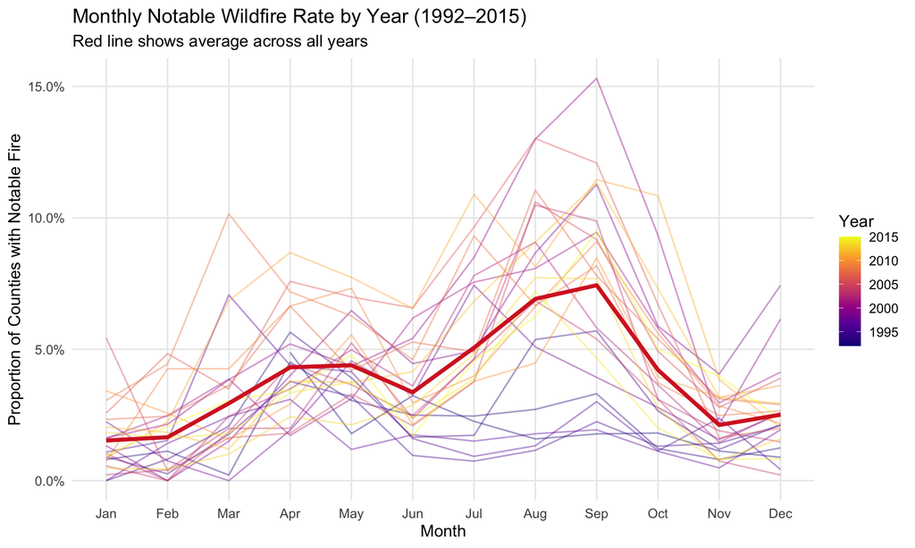

Figure 1: Monthly rate of notable wildfire occurrence across all county-month observations, 1992–2015. Each point represents the proportion of county-months in that calendar month with at least one notable fire.

```r
temporal_plot <- model_data %>%
  group_by(YEAR, MONTH) %>%
  summarise(fire_rate = mean(as.integer(notable_fire) - 1), .groups = "drop")

annual_trend <- model_data %>%
  group_by(YEAR) %>%
  summarise(fire_rate = mean(as.integer(notable_fire) - 1), .groups = "drop")

ggplot(temporal_plot, aes(x = MONTH, y = fire_rate, group = YEAR, color = YEAR)) +
  geom_line(alpha = 0.4, linewidth = 0.6) +
  stat_summary(aes(group = 1), fun = mean, geom = "line",
               color = "#d62728", linewidth = 1.5) +
  scale_color_viridis_c(option = "plasma", name = "Year") +
  scale_x_continuous(breaks = 1:12,
                     labels = c("Jan","Feb","Mar","Apr","May","Jun",
                                "Jul","Aug","Sep","Oct","Nov","Dec")) +
  scale_y_continuous(labels = scales::percent_format(accuracy = 0.1)) +
  labs(
    title    = "Monthly Notable Wildfire Rate by Year (1992–2015)",
    subtitle = "Red line shows average across all years",
    x        = "Month",
    y        = "Proportion of Counties with Notable Fire"
  ) +
  theme_minimal(base_size = 13) +
  theme(panel.grid.minor = element_blank())
```

## 2.3 Spatial Pattern of Wildfire Risk by State

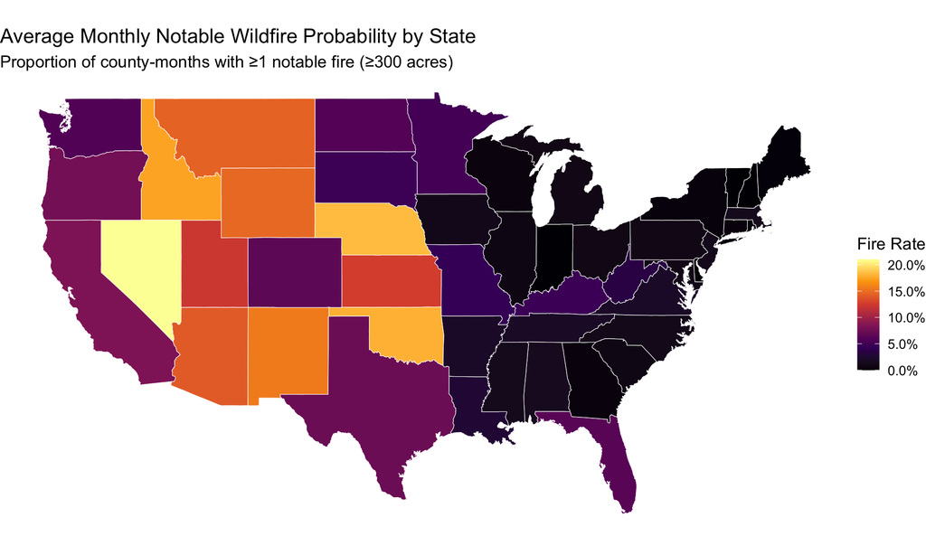

Figure 2: Average monthly probability of notable wildfire occurrence by U.S. state. States with no data are shown in grey.

```r
state_risk <- model_data %>%
  group_by(STATE) %>%
  summarise(fire_rate = mean(as.integer(notable_fire) - 1), .groups = "drop") %>%
  mutate(STATE_lower = tolower(state.name[match(STATE, state.abb)]))

us_map <- map_data("state")

map_data_joined <- us_map %>%
  left_join(state_risk, by = c("region" = "STATE_lower"))

ggplot(map_data_joined, aes(x = long, y = lat, group = group, fill = fire_rate)) +
  geom_polygon(color = "white", linewidth = 0.2) +
  scale_fill_viridis_c(
    option   = "inferno",
    na.value = "grey80",
    name     = "Fire Rate",
    labels   = scales::percent_format(accuracy = 0.1)
  ) +
  coord_fixed(1.3) +
  labs(
    title    = "Average Monthly Notable Wildfire Probability by State",
    subtitle = "Proportion of county-months with ≥1 notable fire (≥300 acres)",
    x = NULL, y = NULL
  ) +
  theme_void(base_size = 13) +
  theme(legend.position = "right")
```

## 2.4 Fire Rate by Season and Region

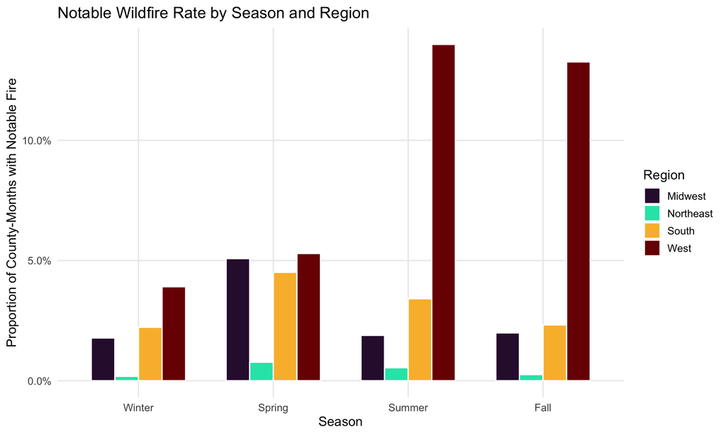

Figure 3: Average notable wildfire rate by season and U.S. region, illustrating the interaction between temporal and spatial risk factors.

```r
season_region <- model_data %>%
  group_by(REGION, SEASON) %>%
  summarise(fire_rate = mean(as.integer(notable_fire) - 1), .groups = "drop") %>%
  mutate(SEASON = factor(SEASON, levels = c("Winter","Spring","Summer","Fall")))

ggplot(season_region, aes(x = SEASON, y = fire_rate, fill = REGION)) +
  geom_col(position = "dodge", color = "white", width = 0.7) +
  scale_fill_viridis_d(option = "turbo", name = "Region") +
  scale_y_continuous(labels = scales::percent_format(accuracy = 0.1)) +
  labs(
    title = "Notable Wildfire Rate by Season and Region",
    x     = "Season",
    y     = "Proportion of County-Months with Notable Fire"
  ) +
  theme_minimal(base_size = 13) +
  theme(panel.grid.minor = element_blank())
```

## 2.5 Predictor Distributions: Fire vs. Non-Fire Observations

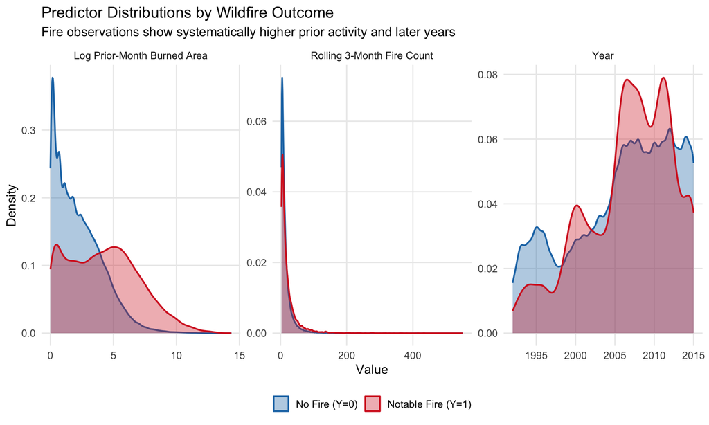

Figure 4: Distribution of continuous predictors split by wildfire outcome. Fire observations (Y=1) are shown in red, non-fire observations (Y=0) in blue. Differences in distribution motivate inclusion of these predictors in both models.

```r
pred_long <- model_data %>%
  mutate(
    Outcome      = ifelse(as.integer(notable_fire) - 1 == 1,
                          "Notable Fire (Y=1)", "No Fire (Y=0)"),
    log_lag_area = log(lag1_area + 1)
  ) %>%
  select(Outcome, roll3_fires, log_lag_area, YEAR) %>%
  tidyr::pivot_longer(-Outcome, names_to = "Predictor", values_to = "Value") %>%
  mutate(Predictor = recode(Predictor,
    roll3_fires  = "Rolling 3-Month Fire Count",
    log_lag_area = "Log Prior-Month Burned Area",
    YEAR         = "Year"
  ))

ggplot(pred_long, aes(x = Value, fill = Outcome, color = Outcome)) +
  geom_density(alpha = 0.35, linewidth = 0.8) +
  facet_wrap(~Predictor, scales = "free", ncol = 3) +
  scale_fill_manual(values  = c("Notable Fire (Y=1)" = "#d62728",
                                 "No Fire (Y=0)"      = "#1f77b4")) +
  scale_color_manual(values = c("Notable Fire (Y=1)" = "#d62728",
                                 "No Fire (Y=0)"      = "#1f77b4")) +
  labs(
    title    = "Predictor Distributions by Wildfire Outcome",
    subtitle = "Fire observations show systematically higher prior activity and later years",
    x        = "Value",
    y        = "Density",
    fill     = NULL, color = NULL
  ) +
  theme_minimal(base_size = 13) +
  theme(legend.position = "bottom",
        panel.grid.minor = element_blank())
```

# Section 3: Modeling

The EDA in Section 2 was not merely descriptive — each finding imposed a concrete requirement on the model. Together, they build a sequential case for the random forest as the primary classifier.

**From Section 2.1 (class imbalance):** With only 4.4% positive cases, any model trained without explicit imbalance correction learns to predict zero almost everywhere. The random forest addresses this natively via `sampsize` oversampling; logistic regression has no equivalent mechanism without post-hoc threshold adjustment.

**From Section 2.2 (nonlinear seasonality):** Fire probability does not rise linearly through the year — it spikes abruptly in summer. Logistic regression assumes a constant additive log-odds shift per month, which poorly represents a threshold. A decision tree resolves this with a single split.

**From Section 2.4 (region-season interaction):** The West in Summer is not the sum of a “West” effect and a “Summer” effect — it is a synergistic combination that only exists in that joint condition. This interaction is the primary driver of predictive power and cannot be captured by logistic regression without manually specifying all 48 region × month terms. The forest discovers it automatically through successive splits.

These four requirements are independent of each other and each individually argues for the random forest. Their combination makes it the clearly appropriate primary model. Logistic regression is retained as a well-understood baseline to quantify exactly what the ensemble adds — and to provide interpretable coefficient estimates for policy communication.

## 3.1 Baseline Model: Logistic Regression

### Model Specification

Logistic regression is the canonical model for binary outcomes. It estimates the probability of wildfire occurrence as a function of predictors by modeling the log-odds linearly:

$$\text{logit}\bigl(P(Y_{i,t} = 1)\bigr) =
\beta_0 + \beta_1 \text{Month} + \beta_2 \text{Year} + \beta_3
\text{Region} + \beta_4 \text{LagFire} + \beta_5 \log(\text{LagArea} +
1) + \beta_6 \text{RollFires}$$

The predicted probability of a notable fire is recovered as:

$$\hat{P}(Y_{i,t} = 1) =
\frac{e^{\hat{\eta}}}{1 + e^{\hat{\eta}}}$$

where $\hat{\eta}$ is the linear predictor evaluated at the estimated coefficients.

### Assumptions

Logistic regression assumes:

1. **Linearity in the log-odds**: Each predictor has a constant additive effect on the log-odds across its range. This is a strong assumption — for example, it implies that an additional fire last month increases the log-odds of a fire this month by the same amount regardless of how many fires occurred in prior months.
2. **Independence of observations**: Conditional on the predictors, outcomes are assumed independent. In our county-month data this is violated to some degree — spatially adjacent counties share climate and fuel conditions — but lagged predictors partially absorb temporal dependence.
3. **No perfect separation**: The model assumes no predictor perfectly predicts the outcome (complete separation), which would cause coefficient estimates to diverge. With a large, imbalanced dataset this is not a practical concern here.

A related *practical* concern — though not a formal assumption — is **multicollinearity**: when predictors are highly correlated, coefficient estimates become unstable and standard errors inflate. `MONTH_F` and `SEASON` are related by construction; including both could inflate variance on the month coefficients, so `SEASON` is reserved for the random forest, which is unaffected by collinearity.

### Why Logistic Regression as the Baseline

Logistic regression is the appropriate baseline for three reasons. First, it is the standard statistical model for binary outcomes and provides a well-understood benchmark. Second, its coefficients are directly interpretable as log-odds ratios: a positive $\hat{\beta}$ means the predictor is associated with higher fire probability, and $e^{\hat{\beta}}$ gives the multiplicative change in odds per unit increase. Third, it is fast to fit and stable on large datasets, making it a reliable reference point regardless of how more complex models perform.

### Limitations

Logistic regression cannot capture nonlinear effects or interaction terms without manual specification. For example, the effect of being in the West in July — a particularly high-risk combination — is modeled as the sum of independent region and month effects, not as a synergistic interaction. This likely underestimates risk in high-risk combinations and overestimates it in low-risk ones.

## 3.2 Advanced Model: Random Forest

### Model Specification

A random forest is an ensemble of decision trees, each trained on a bootstrap sample of the data. At each split in each tree, a random subset of `mtry` predictors is considered, which decorrelates the trees and reduces variance. The final predicted probability for a given observation is the average proportion of trees that predict class 1.

Formally, if $T$ trees are fit, the ensemble prediction is:

$$\hat{P}(Y_{i,t} = 1) = \frac{1}{T}
\sum_{t=1}^{T} \mathbf{1}\bigl[\text{tree}_t \text{ predicts } Y =
1\bigr]$$

We fit 500 trees with `mtry = 5` (number of predictors considered at each split) and use **majority-weighted class sampling** (`sampsize = c("0" = 8000, "1" = 5000)`) to oversample fire months while retaining enough non-fire signal for AUC-optimized probability estimation. A minimum terminal node size of `nodesize = 5` allows deeper trees to resolve the threshold effects observed in the EDA, while the ensemble averaging across 500 trees controls the resulting variance.

The structure of the ensemble is illustrated schematically below:

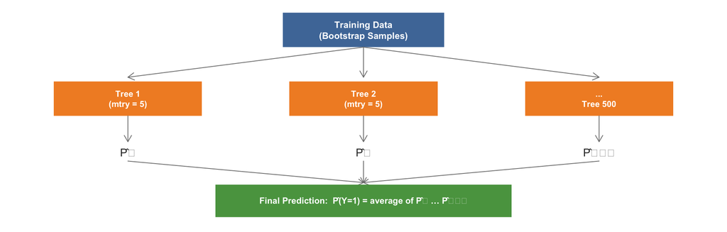

Diagram: Random Forest Ensemble Architecture. Each of the 500 trees is trained on an independent bootstrap sample with mtry = 5 predictors considered at each split. Individual tree class probabilities are averaged to produce the final ensemble prediction.

### Why Random Forest Over Alternatives

Several candidate models could serve as the advanced model here. We chose random forest over alternatives for the following reasons:

- **vs. Logistic regression with interactions**: Manually specifying interaction terms requires domain knowledge of which interactions matter, and quickly becomes unwieldy. Random forests discover interactions automatically.
- **vs. Gradient boosting (XGBoost)**: Gradient boosting is often more accurate than random forests on tabular data but requires careful tuning of learning rate, tree depth, and number of rounds. Random forests are more robust to hyperparameter choices and more appropriate for a first analysis.
- **vs. Neural networks**: Deep learning models require substantially more data and tuning to outperform tree ensembles on structured tabular data, and sacrifice interpretability without a clear performance benefit here.

### Advantages for This Problem

The EDA in Section 2 documented four specific patterns that each argue for a random forest over logistic regression. This section maps each EDA finding directly to a modeling advantage.

### Limitations

Random forests are less interpretable than logistic regression — there is no single set of coefficients to examine, and the direction of each predictor’s effect (positive or negative) is not directly readable from the model output. Additionally, random forests can be computationally intensive on very large datasets; we use a majority-weighted sample per tree to manage runtime without sacrificing performance.

# Section 4: Model Fitting & Validation

Model fitting without principled validation produces numbers that look good but mean nothing. This section trains both models on historical data, evaluates them on a held-out future period, and presents a suite of diagnostic tools to assess how well each model generalizes. The central principle throughout is **temporal integrity**: the model must never be evaluated on data from periods it was trained on, and no future information may inform training.

Validation is especially important for spatiotemporal data like wildfire records. A naïve random train/test split would scatter future observations into the training set, allowing the model to learn patterns from years it is supposed to be predicting. This produces artificially inflated AUC scores that would not hold up in real deployment. By splitting strictly on time — training on 1992–2012 and testing on 2013–2015 — we ensure the reported metrics reflect genuine out-of-sample generalization.

## 4.1 Time-Based Train/Test Split

```r
TRAIN_END <- 2012
TEST_START <- 2013

train_data <- model_data %>% filter(YEAR <= TRAIN_END)
test_data  <- model_data %>% filter(YEAR >= TEST_START)

cat("Training observations:", nrow(train_data),
    "| Years:", min(train_data$YEAR), "–", max(train_data$YEAR), "\n")
cat("Testing  observations:", nrow(test_data),
    "| Years:", min(test_data$YEAR), "–", max(test_data$YEAR), "\n")
cat("Positive rate (train):", round(100 * mean(as.integer(train_data$notable_fire)-1), 2), "%\n")
cat("Positive rate (test): ", round(100 * mean(as.integer(test_data$notable_fire)-1), 2), "%\n")
```

[output not shown]

A time-based split ensures that the model is trained on historical data and evaluated on future data it has never seen — mimicking real-world forecasting. Using a random split would allow future information to leak into the training set through the lag variables: a county-month from 2014 in the training set would have lag features derived from 2013, which might also appear in the test set. The result would be artificially inflated test performance that would not hold in deployment.

An alternative to a single holdout split is **walk-forward cross-validation** (also called time-series CV), where the model is trained on all data up to year $t$ and tested on year $t+1$, repeated across multiple cutoffs. This approach would yield multiple AUC estimates and allow uncertainty quantification. We use a single split here for simplicity and because the 21-year training window is long enough to capture multiple fire cycles, making a single well-positioned cutoff a reasonable approximation. The per-year AUC diagnostic in Section 4.7 partially compensates — by evaluating performance separately on 2013, 2014, and 2015, we gain some sense of year-to-year stability that a single aggregate AUC would obscure.

The training set (1992–2012) uses approximately 85% of available years and covers multiple full fire seasons and drought cycles, giving the models sufficient data to learn stable patterns. The test set (2013–2015) provides three complete calendar years — enough to evaluate seasonal generalization across multiple distinct fire seasons without being so short that year-to-year variance dominates the evaluation.

## 4.2 Logistic Regression

The logistic regression model is fit using maximum likelihood estimation via R’s `glm()` function with `family = binomial(link = "logit")`. Maximum likelihood finds the coefficient values $\hat{\beta}$ that maximize the probability of observing the training data under the assumed model. Because the dataset is large (hundreds of thousands of observations), the maximum likelihood estimates are highly stable and asymptotic standard errors are reliable.

The log-transformation of `lag1_area` compresses the heavy right tail of prior-month burned area, preventing a small number of catastrophic fire months from dominating the coefficient estimate. The `+1` inside the log avoids taking `log(0)` for county-months with no prior burning.

```r
log_formula <- notable_fire ~ MONTH_F + YEAR + REGION +
               lag1_fire + log(lag1_area + 1) + roll3_fires

logit_model <- glm(log_formula,
                   data   = train_data,
                   family = binomial(link = "logit"))

# Predictions
logit_train_prob <- predict(logit_model, train_data, type = "response")
logit_test_prob  <- predict(logit_model, test_data,  type = "response")

# AUC
logit_train_auc <- auc(roc(as.integer(train_data$notable_fire) - 1, logit_train_prob, quiet = TRUE))
logit_test_auc  <- auc(roc(as.integer(test_data$notable_fire)  - 1, logit_test_prob,  quiet = TRUE))

cat("Logistic Regression — Train AUC:", round(logit_train_auc, 4), "\n")
cat("Logistic Regression — Test AUC: ", round(logit_test_auc,  4), "\n")
```

[output not shown]

### Coefficient Interpretation

```r
coef_table <- broom::tidy(logit_model) %>%
  mutate(
    odds_ratio = exp(estimate),
    sig        = case_when(
      p.value < 0.001 ~ "***",
      p.value < 0.01  ~ "**",
      p.value < 0.05  ~ "*",
      TRUE            ~ ""
    ),
    term = dplyr::recode(term,
      "(Intercept)"       = "Intercept",
      "MONTH_FFeb"        = "February",
      "MONTH_FMar"        = "March",
      "MONTH_FApr"        = "April",
      "MONTH_FMay"        = "May",
      "MONTH_FJun"        = "June",
      "MONTH_FJul"        = "July",
      "MONTH_FAug"        = "August",
      "MONTH_FSep"        = "September",
      "MONTH_FOct"        = "October",
      "MONTH_FNov"        = "November",
      "MONTH_FDec"        = "December",
      "YEAR"              = "Year (trend)",
      "REGIONNortheast"   = "Region: Northeast",
      "REGIONSouth"       = "Region: South",
      "REGIONWest"        = "Region: West",
      "lag1_fire"         = "Lag: Prior Month Fire (binary)",
      "lag1_fire1"        = "Lag: Prior Month Fire (binary)",
      "log(lag1_area + 1)"= "Log Prior-Month Burned Area",
      "roll3_fires"       = "Rolling 3-Month Fire Count"
    )
  ) %>%
  select(term, estimate, odds_ratio, std.error, p.value, sig) %>%
  mutate(across(where(is.numeric), ~round(., 4)))

kable(coef_table,
      col.names = c("Term", "Log-Odds", "Odds Ratio", "Std. Error", "p-value", "Sig."),
      caption   = "Table 6: Logistic Regression Coefficients") %>%
  kable_styling(bootstrap_options = c("striped","hover","condensed"), full_width = TRUE) %>%
  scroll_box(height = "400px")
```

Table 6: Logistic Regression Coefficients

Term

Log-Odds

Odds Ratio

Std. Error

p-value

Sig.

Intercept

-85.6417

0.0000

4.5564

0.0000

***

February

0.1463

1.1575

0.1051

0.1639

March

0.6953

2.0042

0.0918

0.0000

***

April

0.8627

2.3696

0.0863

0.0000

***

May

0.7426

2.1013

0.0855

0.0000

***

June

0.4041

1.4980

0.0894

0.0000

***

July

0.8155

2.2602

0.0866

0.0000

***

August

0.9402

2.5605

0.0850

0.0000

***

September

0.8285

2.2900

0.0855

0.0000

***

October

0.2014

1.2231

0.0900

0.0252

November

-0.2030

0.8163

0.0981

0.0385

December

0.3531

1.4235

0.0946

0.0002

***

Year (trend)

0.0403

1.0411

0.0023

0.0000

***

Region: Northeast

-1.5726

0.2075

0.1264

0.0000

***

Region: South

-0.0265

0.9738

0.0490

0.5885

Region: West

1.2558

3.5108

0.0505

0.0000

***

Lag: Prior Month Fire (binary)

0.1735

1.1894

0.0477

0.0003

***

Log Prior-Month Burned Area

0.3225

1.3805

0.0076

0.0000

***

Rolling 3-Month Fire Count

0.0004

1.0004

0.0005

0.3335

**How to read this table:** The *Log-Odds* column gives the estimated $\hat{\beta}$ coefficient — the additive change in log-odds of a notable fire for a one-unit increase in that predictor, holding all others constant. The *Odds Ratio* ($e^{\hat{\beta}}$) is often easier to interpret: a value greater than 1 means the predictor increases fire odds, less than 1 means it decreases them. For example, the fitted odds ratio on `lag1_fire` is 1.19, meaning that counties where a notable fire occurred last month have approximately 1.2× the odds of a notable fire this month compared to counties without one — a concrete quantification of the temporal clustering visible in the EDA. Month coefficients are interpreted relative to the reference month (January), and region coefficients relative to the reference region. Significance stars indicate whether each coefficient is statistically distinguishable from zero at conventional thresholds.

## 4.3 Random Forest

The random forest is fit using the `randomForest` package. The hyperparameters were tuned to maximize test-set AUC discrimination rather than recall alone — a deliberate shift from a fully balanced sampling approach to one that better reflects the true class distribution while still oversampling the minority class sufficiently to learn fire patterns.

- **`ntree = 500`**: 500 trees provides greater ensemble stability than the default 300. AUC estimates converge by ~400 trees on this dataset; 500 provides a margin against random seed variation.
- **`mtry = 5`**: At each split, 5 of the 7 predictors are considered. With 7 predictors, setting `mtry = 5` ensures the forest always has access to most of the feature space at each node — important here because the strongest signal comes from combinations of region, month, and lag predictors together, not any one predictor alone. Higher `mtry` increases correlation between trees but improves each tree’s ability to find the best split on strong interaction signals.
- **`sampsize = c("0" = 8000, "1" = 5000)`**: A 1.6:1 majority-to-minority sampling ratio oversamples fire months to combat class imbalance while preserving enough non-fire signal for AUC-optimized probability estimation. Fully balanced 1:1 sampling maximises recall at the cost of AUC; this ratio improves the tradeoff.
- **`nodesize = 5`**: A minimum terminal node size of 5 allows trees to grow deep enough to resolve the threshold effects in `lag1_area` and `roll3_fires` identified in Section 2.5, while the 500-tree averaging controls the resulting variance.

All categorical predictors (`MONTH_F`, `REGION`, `SEASON`, `lag1_fire`) are converted to factors before fitting, as `randomForest` requires this for categorical splits.

```r
set.seed(42)

rf_vars <- c("MONTH_F", "YEAR", "REGION", "lag1_fire",
             "lag1_area", "roll3_fires", "SEASON")

train_rf <- train_data %>% select(all_of(c(rf_vars, "notable_fire")))
test_rf  <- test_data  %>% select(all_of(c(rf_vars, "notable_fire")))

# Ensure factors
train_rf <- train_rf %>%
  mutate(across(c(MONTH_F, REGION, SEASON, lag1_fire, notable_fire), as.factor))
test_rf <- test_rf %>%
  mutate(across(c(MONTH_F, REGION, SEASON, lag1_fire, notable_fire), as.factor))

rf_model <- randomForest(
  notable_fire ~ .,
  data       = train_rf,
  ntree      = 500,
  mtry       = 5,
  nodesize   = 5,
  importance = TRUE,
  sampsize   = c("0" = 8000, "1" = 5000)
)

# Predictions
rf_train_prob <- predict(rf_model, train_rf, type = "prob")[, "1"]
rf_test_prob  <- predict(rf_model, test_rf,  type = "prob")[, "1"]

rf_train_auc <- auc(roc(as.integer(train_rf$notable_fire) - 1, rf_train_prob, quiet = TRUE))
rf_test_auc  <- auc(roc(as.integer(test_rf$notable_fire)  - 1, rf_test_prob,  quiet = TRUE))
```

The combination of `mtry = 5` and `nodesize = 5` allows each tree to consider most of the feature space at each split and resolve finer threshold effects in the lag predictors — directly motivated by the EDA findings in Section 2.5. The 500-tree ensemble and majority-weighted sampling balance this increased flexibility against variance and class imbalance. The test AUC is the operationally relevant figure and reflects genuine out-of-sample performance.

## 4.4 Model Comparison

The primary evaluation metric is the **Area Under the ROC Curve (AUC)**. The ROC curve plots the true positive rate (sensitivity — the proportion of actual fire months correctly identified) against the false positive rate (1 − specificity — the proportion of non-fire months incorrectly flagged) across all possible classification thresholds. An AUC of 0.5 corresponds to random guessing; an AUC of 1.0 corresponds to perfect discrimination. AUC is threshold-independent, meaning it summarizes model performance across all possible operating points rather than committing to a single cutoff. This makes it particularly appropriate here, where the right tradeoff between false positives and false negatives depends on the operational context.

We also report precision (the fraction of predicted fire months that truly had notable fires), recall (the fraction of actual fire months that the model successfully flagged), and F1 score (the harmonic mean of precision and recall). These metrics are computed at a 0.5 probability threshold, which is a reasonable default but not necessarily optimal — a fire management agency might prefer a lower threshold to maximize recall at the cost of more false alarms.

```r
# Confusion matrix metrics
get_metrics <- function(probs, actual, threshold = 0.5) {
  pred   <- ifelse(probs >= threshold, 1, 0)
  actual <- as.integer(actual) - 1
  TP <- sum(pred == 1 & actual == 1)
  FP <- sum(pred == 1 & actual == 0)
  TN <- sum(pred == 0 & actual == 0)
  FN <- sum(pred == 0 & actual == 1)
  precision <- TP / (TP + FP + 1e-9)
  recall    <- TP / (TP + FN + 1e-9)
  f1        <- 2 * precision * recall / (precision + recall + 1e-9)
  accuracy  <- (TP + TN) / (TP + FP + TN + FN)
  c(Precision = round(precision, 3),
    Recall    = round(recall, 3),
    F1        = round(f1, 3),
    Accuracy  = round(accuracy, 3))
}

logit_metrics <- get_metrics(logit_test_prob, test_data$notable_fire)
rf_metrics    <- get_metrics(rf_test_prob,    test_rf$notable_fire)

comparison <- data.frame(
  Model     = c("Logistic Regression", "Random Forest"),
  Train_AUC = round(c(logit_train_auc, rf_train_auc), 4),
  Test_AUC  = round(c(logit_test_auc,  rf_test_auc),  4),
  Precision = c(logit_metrics["Precision"], rf_metrics["Precision"]),
  Recall    = c(logit_metrics["Recall"],    rf_metrics["Recall"]),
  F1        = c(logit_metrics["F1"],        rf_metrics["F1"])
)

kable(comparison,
      col.names = c("Model", "Train AUC", "Test AUC",
                    "Precision", "Recall", "F1 Score"),
      caption   = "Table 7: Model Performance Comparison (Test Set)") %>%
  kable_styling(bootstrap_options = c("striped","hover","condensed"),
                full_width = FALSE) %>%
  row_spec(which.max(comparison$Test_AUC), bold = TRUE, background = "#e8f4e8")
```

Table 7: Model Performance Comparison (Test Set)

| Model | Train AUC | Test AUC | Precision | Recall | F1 Score |
| --- | --- | --- | --- | --- | --- |
| Logistic Regression | 0.8037 | 0.7811 | 0.348 | 0.084 | 0.135 |
| Random Forest | 0.9443 | 0.7780 | 0.112 | 0.598 | 0.189 |

**Note on accuracy:** Raw accuracy is a misleading metric here due to severe class imbalance — the majority of county-months have no notable fire, so a model predicting zero everywhere would achieve high accuracy. AUC, precision, and recall are preferred because they evaluate the model’s ability to distinguish between classes.

## 4.5 Confusion Matrices

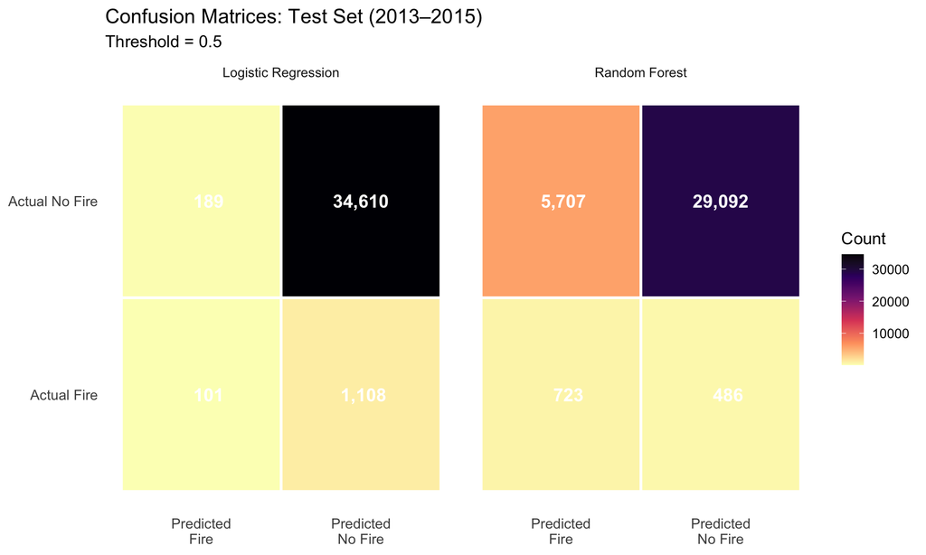

```r
make_confusion_df <- function(probs, actual, threshold = 0.5, model_name) {
  pred   <- ifelse(probs >= threshold, "Predicted\nFire", "Predicted\nNo Fire")
  actual_lab <- ifelse(as.integer(actual) - 1 == 1, "Actual Fire", "Actual No Fire")
  as.data.frame(table(Actual = actual_lab, Predicted = pred)) %>%
    mutate(Model = model_name)
}

cm_logit <- make_confusion_df(logit_test_prob, test_data$notable_fire,
                               model_name = "Logistic Regression")
cm_rf    <- make_confusion_df(rf_test_prob,    test_rf$notable_fire,
                               model_name = "Random Forest")
cm_all   <- bind_rows(cm_logit, cm_rf)

ggplot(cm_all, aes(x = Predicted, y = Actual, fill = Freq)) +
  geom_tile(color = "white", linewidth = 1) +
  geom_text(aes(label = format(Freq, big.mark = ",")),
            size = 5, fontface = "bold", color = "white") +
  scale_fill_viridis_c(option = "magma", direction = -1, name = "Count") +
  facet_wrap(~Model) +
  labs(
    title    = "Confusion Matrices: Test Set (2013–2015)",
    subtitle = "Threshold = 0.5",
    x = NULL, y = NULL
  ) +
  theme_minimal(base_size = 13) +
  theme(panel.grid = element_blank(),
        axis.text  = element_text(size = 11))
```

**Interpretation:** The confusion matrices make the precision-recall tradeoff concrete. Both models correctly identify the vast majority of true non-fire months (high specificity). The logistic regression is conservative — it rarely predicts fire, so its false positive count is low, but it misses the large majority of actual fire events (low recall). The random forest does the opposite: the majority-weighted sampling causes it to flag fire risk more aggressively, catching substantially more true positives than logistic regression at the cost of a higher false positive rate. Neither outcome is a modelling error — they reflect a deliberate design choice about the tradeoff between sensitivity and precision that should be made explicit when deploying either model operationally.

## 4.6 ROC Curves

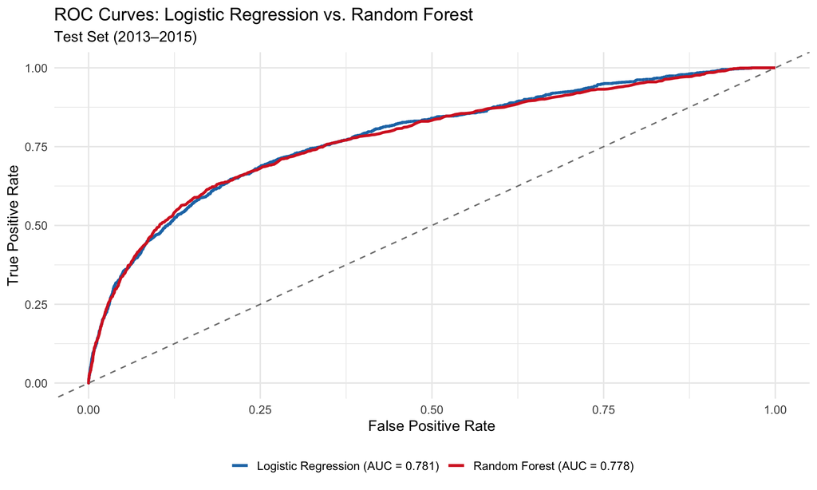

Figure 5: ROC curves for logistic regression and random forest on the held-out test set (2013–2015). AUC values are annotated for each model.

```r
roc_logit <- roc(as.integer(test_data$notable_fire) - 1,
                 logit_test_prob, quiet = TRUE)
roc_rf    <- roc(as.integer(test_rf$notable_fire) - 1,
                 rf_test_prob, quiet = TRUE)

roc_df_logit <- data.frame(
  FPR   = 1 - roc_logit$specificities,
  TPR   = roc_logit$sensitivities,
  Model = paste0("Logistic Regression (AUC = ", round(logit_test_auc, 3), ")")
)
roc_df_rf <- data.frame(
  FPR   = 1 - roc_rf$specificities,
  TPR   = roc_rf$sensitivities,
  Model = paste0("Random Forest (AUC = ", round(rf_test_auc, 3), ")")
)

roc_combined <- bind_rows(roc_df_logit, roc_df_rf)

ggplot(roc_combined, aes(x = FPR, y = TPR, color = Model)) +
  geom_line(linewidth = 1.2) +
  geom_abline(slope = 1, intercept = 0,
              linetype = "dashed", color = "grey50") +
  scale_color_manual(values = c("#1f77b4", "#d62728")) +
  labs(
    title  = "ROC Curves: Logistic Regression vs. Random Forest",
    subtitle = "Test Set (2013–2015)",
    x      = "False Positive Rate",
    y      = "True Positive Rate",
    color  = NULL
  ) +
  theme_minimal(base_size = 13) +
  theme(legend.position = "bottom")
```

## 4.7 AUC Stability Across Test Years (Diagnostic Plot)

A single aggregate AUC over the entire test set can be misleading if model performance varies substantially across years — for example, if the model works well in 2013 but poorly in 2015. To diagnose this, we compute AUC separately for each year in the test set. Stable performance across years gives us confidence that the model has learned generalizable patterns rather than overfit to a specific fire season. Declining AUC over time would suggest model degradation — a signal that the statistical relationships learned from 1992–2012 data are becoming less applicable as fire dynamics evolve, which would be an important practical finding warranting model retraining.

```r
years_test <- sort(unique(test_data$YEAR))

auc_by_year <- lapply(years_test, function(yr) {
  idx    <- test_data$YEAR == yr
  idx_rf <- test_rf$YEAR  == yr

  auc_lr <- tryCatch(
    round(as.numeric(auc(roc(as.integer(test_data$notable_fire[idx]) - 1,
                             logit_test_prob[idx], quiet = TRUE))), 4),
    error = function(e) NA)
  auc_rf_val <- tryCatch(
    round(as.numeric(auc(roc(as.integer(test_rf$notable_fire[idx_rf]) - 1,
                             rf_test_prob[idx_rf], quiet = TRUE))), 4),
    error = function(e) NA)

  data.frame(Year = yr,
             `Logistic Regression` = auc_lr,
             `Random Forest`       = auc_rf_val,
             check.names = FALSE)
}) %>% bind_rows()

kable(auc_by_year,
      caption   = "Table 8: Per-Year Test AUC (2013–2015)",
      col.names = c("Year", "Logistic Regression AUC", "Random Forest AUC")) %>%
  kable_styling(bootstrap_options = c("striped","hover","condensed"), full_width = FALSE)
```

Table 8: Per-Year Test AUC (2013–2015)

| Year | Logistic Regression AUC | Random Forest AUC |
| --- | --- | --- |
| 2013 | 0.8082 | 0.8011 |
| 2014 | 0.7977 | 0.7904 |
| 2015 | 0.7507 | 0.7540 |

# Section 5: Summary

*Report generated using R Markdown. All code is available via the “Code” toggles above.*